# Upstream AI — Pitch

Upstream AI

← → navigate

01 / 06

upstream ai

🛀 Wastewater & Sanitation Intelligence

It's MLK Day. The slopes are packed. Rob is on his day off — exactly where he should be. Meanwhile, at the *wastewater facility*, an **air-actuated valve installed in the 1970s quietly fails.**

On-call staff search for answers. The O&M manual is **buried on a dusty shelf, long forgotten.** Nobody has operated this valve manually in decades — that knowledge retired years ago. Meanwhile, **influent wastewater keeps pouring in. Tanks begin to fill.**

More staff are called in. Costs rise. Morale — already stretched thin — takes another hit. And none of it needed to happen. **Intelligent early alerts would have caught this before it became a crisis.**

Rob had to leave the mountain, drive back to the plant, and hit three buttons — because the institutional knowledge of how that system worked **lived only in his head.** That moment is the exact problem Upstream AI solves. We are not building for an abstract market. **We are building the tool Rob needed.**

Colorado River Basin Idea Factory 2026

The Problem

## Rural utilities are running on *institutional knowledge alone.*

America's **45,000+ small water and wastewater utilities** are the invisible backbone of public health. Most are staffed by one to three people managing complex treatment systems with decades-old equipment, minimal IT support, and no data intelligence layer. When something breaks, the fix lives in someone's head — or it doesn't exist at all.

With **1 in 3 experienced operators nearing retirement**, that institutional knowledge is walking out the door — and there's no system in place to capture it before it's gone.

45K

small utilities across the U.S. — most without a data intelligence layer of any kind

🟢

Equipment That Outlives Its Documentation

Valves, pumps, and systems from the 1970s are still in daily operation. O&M manuals are lost, incomplete, or written for operators who retired long ago.

⚠️

Failures Escalate Before Anyone Notices

Without predictive monitoring, a slowly failing valve becomes a full-facility crisis. Influent keeps flowing while staff scramble — raising costs and straining already small teams.

📋

No Unified View of the System

SCADA data, paper logs, and institutional knowledge exist in silos. No single operator can see the full picture of their facility's health at a glance.

🧠

Expertise Has No Succession Plan

When the veteran operator retires — or has to leave the mountain — the knowledge that kept the system running goes with them. There's no playbook. No memory. No backup.

The Hidden Cost

$40K+

"When in doubt, pour it out." Without real-time process intelligence, operators add more chlorine, more coagulant, more polymer — just to feel safe. It's expensive, and it creates its own compliance risks.

30–50%

**Chlorine Over-Dosed**Excess residual from manual guesswork

Creates disinfection byproducts (DBPs) — a compliance risk in their own right — and taste complaints from residents who notice the difference in their tap water.

20–40%

**Coagulant & Polymer Waste**Dosed without real-time turbidity feedback

Chemical pumps are set conservatively high and left alone. No one watches the turbidity response in real time. Waste compounds every single day, invisibly.

Upstream AI

**Closes the Loop**Sensor data → AI recommendation → right dose

Real-time process feedback means operators dose with confidence, not anxiety. Less chemical. Better water. Typically $3,000–$6,000/year saved per facility.

The Platform

## One *smart brain* for the whole system.

Upstream AI watches your wastewater & water facility around the clock, scores every reading for reliability, and tells operators what needs attention — before it becomes a crisis.

01

Unified System Overview

WTP and WWTP in one dashboard. Every metric, every alert — in plain language. Not fifty sensor screens.

02

Data Trust Engine

Every reading gets a confidence score. Chlorine at Trust 38%? Don't dose from that probe. Operators know what to believe before acting.

03

Predictive Alerts — Before Failures

Intelligent early warnings identify degrading equipment and process drift weeks before a valve fails, a pump seizes, or an alarm sounds at 2am.

04

Institutional Knowledge Vault

Captures operator expertise, process adjustments, and facility history. When the veteran retires, their knowledge stays in the system.

05

Mobile-First Design

Full plant status in under 10 seconds — from the truck, from home, from anywhere. Designed for operators, not engineers.

[figure not shown]

Core Feature — Morning Briefing

## Before the operator arrives, *the AI has already been watching all night.*

[figure not shown]

📋

Overnight Summary — Automatic

Flow spikes, sensor anomalies, auto-adjustments — all summarized in plain language. No manual log review. The AI watched so the operator could sleep.

★ SIGNATURE FEATURE

✅

Your 3 Items Today — Prioritized

Not 400 alarms. Three specific, ranked tasks: check aeration diffusers, pull settleability test, calibrate chlorine probe. The operator knows exactly where to start.

REPLACES GUESSWORK

⚡

Adjustments I Made — Transparent

Every automated action logged with a Trust score. RAS increased to handle flow spike — Trust 89%. Operators stay in control. Every decision is visible and reversible.

AVG TRUST: 87%

🌧️

Weather Impact — Pre-Positioned

Rain Thursday–Friday means 30–45% flow increase. Upstream AI flags it before it happens and pre-adjusts the system. No more surprise callouts.

The Team · The Ask

## Built by people who *lived the problem.*

Rob spent years as an operations manager at a **wastewater & sanitation facility in the Vail Valley** — on call 24/7, managing aging equipment, watching veteran operators retire and take decades of process knowledge with them. He didn't study this from a distance. **He built Upstream AI because he needed it and it didn't exist.**

Katrina brings a decade of experience in **software integrations and digital product development** — the technical bridge that turns operational data into platforms operators actually want to use every day.

Attending the **Colorado Rural Water Association** March 16–18. Onboarding first pilot utilities this spring.

⚖️

Regulatory Navigation

Introductions to former EPA or State Water Quality Board members who can help us streamline our Automated Compliance module to meet specific state reporting standards.

🔒

Security & Edge Expertise

Advisors with ICS/SCADA cybersecurity expertise to ensure our Data Trust layer is impenetrable as we deploy AI agents into critical infrastructure.

🤝

Strategic Partnerships

SCADA hardware integrators tired of being blamed for "bad data" — we want to offer our intelligence layer as a value-add to their existing clients.

📈

Narrative Mentorship

Entrepreneurs who have successfully scaled high-volume, low-touch SaaS in traditional, non-tech industries.

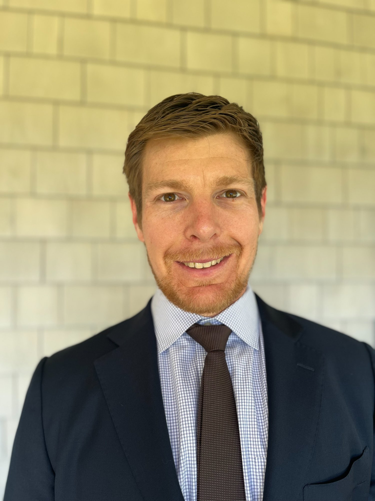

Rob

Co-Founder · Water & Wastewater Ops

Operations manager at a Vail Valley wastewater & sanitation facility. Lived every problem Upstream AI solves — the 2am calls, the holiday callouts, the knowledge that existed only in his head.

10+ yrs Wastewater Operations

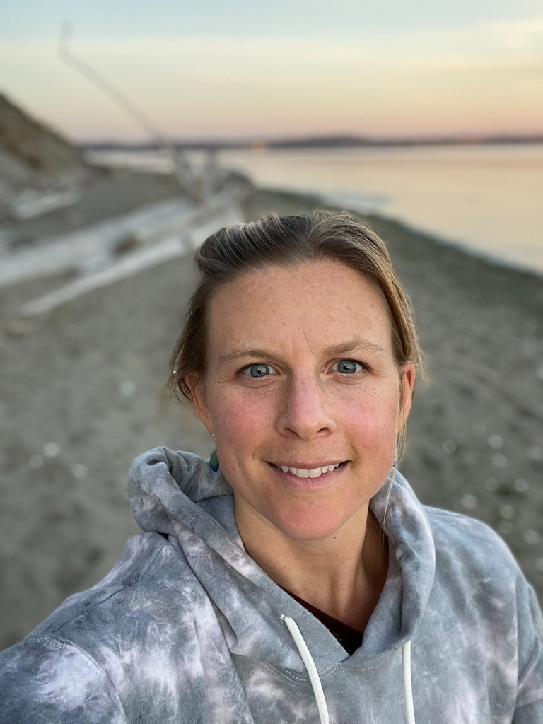

Katrina

Co-Founder · Product & Technology

A decade building software integrations and digital experiences across martech and enterprise platforms. Translates complex operational data into products operators actually use.

10+ yrs Software & Digital Product

upstream ai

WASTEWATER & WATER INTELLIGENCE

$600/mo · No long-term contract · 30-day results